# Predicting Borrowers Viability

2023-10-23

#### Project Background

In the present-day context, the demand for loans is on the rise due to a multitude of factors. This growing need for loans has given rise to a diverse array of entities, including peer-to-peer lending platforms, banks, and more, that provide financial assistance. The ensuing concern revolves around whether these disbursed loans will be repaid in their entirety or not.

### Major Task 1 - Load, Prepare, and Explore Data

#### 3. Add the basic code to your notebook to explain the problem and load the libraries.

```r
# Load required libraries
library(tidyverse, warn.conflicts=FALSE)
library(rsample, warn.conflicts=FALSE)
library(yardstick, warn.conflicts = FALSE)
library(rpart, warn.conflicts=FALSE)
library(bnlearn, warn.conflicts=FALSE)
library(randomForest, warn.conflicts=FALSE)
library(xgboost, warn.conflicts=FALSE)
library(dplyr, warn.conflicts=FALSE)
```

```r
set.seed(1457)
```

#### 4. Load the data file and do basic cleanup and type conversion. The data is mostly clean, but you’ll need to convert some variables to factors, for example.

```r
# Load the data from a CSV file
sba = read.delim('SBAcase.11.13.17.csv', header = TRUE, sep = ",")

glimpse(sba)
```

```
## Rows: 2,102
## Columns: 35
## $ Selected          <int> 0, 1, 0, 1, 1, 1, 0, 0, 0, 1, 1, 1, 0, 1, 1, 1, 1, 0…
## $ LoanNr_ChkDgt     <dbl> 1004285007, 1004535010, 1005005006, 1005535001, 1005…
## $ Name              <chr> "SIMPLEX OFFICE SOLUTIONS", "DREAM HOME REALTY", "Wi…
## $ City              <chr> "ANAHEIM", "TORRANCE", "SAN DIEGO", "SAN DIEGO", "LO…
## $ State             <chr> "CA", "CA", "CA", "CA", "CA", "CA", "CA", "CA", "CA"…
## $ Zip               <int> 92801, 90505, 92103, 92108, 91345, 95831, 90255, 908…
## $ Bank              <chr> "CALIFORNIA BANK & TRUST", "CALIFORNIA BANK & TRUST"…
## $ BankState         <chr> "CA", "CA", "CA", "CA", "CO", "CA", "OH", "NV", "NC"…
## $ NAICS             <int> 532420, 531210, 531210, 531312, 531390, 531210, 5312…
## $ ApprovalDate      <int> 15074, 15130, 15188, 15719, 16840, 15813, 16841, 168…
## $ ApprovalFY        <int> 2001, 2001, 2001, 2003, 2006, 2003, 2006, 2006, 2004…
## $ Term              <int> 36, 56, 36, 36, 240, 84, 269, 84, 22, 84, 64, 84, 84…
## $ NoEmp             <int> 1, 1, 10, 6, 65, 1, 2, 1, 5, 4, 6, 1, 12, 2, 8, 13, …
```

[output cut: 22 more lines]

```r
sba  = sba %>%
  mutate(across(UrbanRural | New | RealEstate | Recession, as.logical),
         LowDoc = LowDoc %in% c("Y", "T"),
         RevLineCr = RevLineCr %in% c("Y","T"))
glimpse(sba)
```

```
## Rows: 2,102
## Columns: 35
## $ Selected          <int> 0, 1, 0, 1, 1, 1, 0, 0, 0, 1, 1, 1, 0, 1, 1, 1, 1, 0…
## $ LoanNr_ChkDgt     <dbl> 1004285007, 1004535010, 1005005006, 1005535001, 1005…
## $ Name              <chr> "SIMPLEX OFFICE SOLUTIONS", "DREAM HOME REALTY", "Wi…
## $ City              <chr> "ANAHEIM", "TORRANCE", "SAN DIEGO", "SAN DIEGO", "LO…
## $ State             <chr> "CA", "CA", "CA", "CA", "CA", "CA", "CA", "CA", "CA"…
## $ Zip               <int> 92801, 90505, 92103, 92108, 91345, 95831, 90255, 908…
## $ Bank              <chr> "CALIFORNIA BANK & TRUST", "CALIFORNIA BANK & TRUST"…
## $ BankState         <chr> "CA", "CA", "CA", "CA", "CO", "CA", "OH", "NV", "NC"…
## $ NAICS             <int> 532420, 531210, 531210, 531312, 531390, 531210, 5312…
## $ ApprovalDate      <int> 15074, 15130, 15188, 15719, 16840, 15813, 16841, 168…
## $ ApprovalFY        <int> 2001, 2001, 2001, 2003, 2006, 2003, 2006, 2006, 2004…
## $ Term              <int> 36, 56, 36, 36, 240, 84, 269, 84, 22, 84, 64, 84, 84…
## $ NoEmp             <int> 1, 1, 10, 6, 65, 1, 2, 1, 5, 4, 6, 1, 12, 2, 8, 13, …
```

[output cut: 22 more lines]

#### 5. Drop all outcome columns except for “Default”. An outcome column is a column that records information about the final outcome of the loan, such as the amount charged off. The outcome variables are MIS_Status, BalanceGross, ChgOffPrinGr, and ChgOffDate. Also remove the Selected, xx, and daysterm columns. You may need to further transform the outcome variable to be a factor instead of a logical (my example code does this).

```r
sba_new = sba %>%
  select(-xx, -daysterm, -Selected, -NewExist) %>%
  select(-MIS_Status, -ChgOffPrinGr, -ChgOffDate)

glimpse(sba_new)
```

```
## Rows: 2,102
## Columns: 28
## $ LoanNr_ChkDgt     <dbl> 1004285007, 1004535010, 1005005006, 1005535001, 1005…
## $ Name              <chr> "SIMPLEX OFFICE SOLUTIONS", "DREAM HOME REALTY", "Wi…
## $ City              <chr> "ANAHEIM", "TORRANCE", "SAN DIEGO", "SAN DIEGO", "LO…
## $ State             <chr> "CA", "CA", "CA", "CA", "CA", "CA", "CA", "CA", "CA"…
## $ Zip               <int> 92801, 90505, 92103, 92108, 91345, 95831, 90255, 908…
## $ Bank              <chr> "CALIFORNIA BANK & TRUST", "CALIFORNIA BANK & TRUST"…
## $ BankState         <chr> "CA", "CA", "CA", "CA", "CO", "CA", "OH", "NV", "NC"…
## $ NAICS             <int> 532420, 531210, 531210, 531312, 531390, 531210, 5312…
## $ ApprovalDate      <int> 15074, 15130, 15188, 15719, 16840, 15813, 16841, 168…
## $ ApprovalFY        <int> 2001, 2001, 2001, 2003, 2006, 2003, 2006, 2006, 2004…
## $ Term              <int> 36, 56, 36, 36, 240, 84, 269, 84, 22, 84, 64, 84, 84…
## $ NoEmp             <int> 1, 1, 10, 6, 65, 1, 2, 1, 5, 4, 6, 1, 12, 2, 8, 13, …
## $ CreateJob         <int> 0, 0, 0, 0, 3, 0, 0, 2, 0, 0, 0, 0, 0, 0, 0, 7, 0, 0…
## $ RetainedJob       <int> 0, 0, 0, 0, 65, 0, 2, 1, 0, 0, 0, 0, 0, 2, 0, 20, 0,…
## $ FranchiseCode     <int> 1, 1, 1, 1, 1, 1, 1, 1, 1, 1, 1, 1, 1, 1, 1, 1, 1, 1…
## $ UrbanRural        <lgl> FALSE, FALSE, FALSE, FALSE, TRUE, FALSE, TRUE, TRUE,…
## $ RevLineCr         <lgl> TRUE, TRUE, TRUE, TRUE, FALSE, TRUE, FALSE, TRUE, FA…
## $ LowDoc            <lgl> FALSE, FALSE, FALSE, FALSE, FALSE, FALSE, FALSE, FAL…
## $ DisbursementDate  <int> 15095, 15978, 15218, 15736, 16903, 15825, 16860, 168…
## $ DisbursementGross <int> 32812, 30000, 30000, 50000, 343000, 55825, 297500, 6…
## $ BalanceGross      <int> 0, 0, 0, 0, 0, 0, 0, 0, 0, 0, 0, 0, 0, 0, 0, 0, 0, 0…
## $ GrAppv            <int> 30000, 30000, 30000, 50000, 343000, 50000, 297500, 3…
## $ SBA_Appv          <int> 15000, 15000, 15000, 25000, 343000, 25000, 223125, 1…
## $ New               <lgl> FALSE, FALSE, FALSE, FALSE, FALSE, FALSE, FALSE, TRU…
## $ RealEstate        <lgl> FALSE, FALSE, FALSE, FALSE, TRUE, FALSE, TRUE, FALSE…
## $ Portion           <dbl> 0.50, 0.50, 0.50, 0.50, 1.00, 0.50, 0.75, 0.50, 0.50…
## $ Recession         <lgl> FALSE, TRUE, FALSE, FALSE, FALSE, FALSE, FALSE, FALS…
## $ Default           <int> 0, 0, 0, 0, 0, 0, 1, 0, 1, 0, 1, 0, 0, 1, 0, 0, 0, 0…
```

```r
sba_p = sba_new %>%
  select(-LoanNr_ChkDgt, -Name, -City, -State, -Zip, -Bank, -BankState, -NAICS, -ApprovalDate)

glimpse(sba_p)
```

```
## Rows: 2,102
## Columns: 19
## $ ApprovalFY        <int> 2001, 2001, 2001, 2003, 2006, 2003, 2006, 2006, 2004…
## $ Term              <int> 36, 56, 36, 36, 240, 84, 269, 84, 22, 84, 64, 84, 84…
## $ NoEmp             <int> 1, 1, 10, 6, 65, 1, 2, 1, 5, 4, 6, 1, 12, 2, 8, 13, …
## $ CreateJob         <int> 0, 0, 0, 0, 3, 0, 0, 2, 0, 0, 0, 0, 0, 0, 0, 7, 0, 0…
## $ RetainedJob       <int> 0, 0, 0, 0, 65, 0, 2, 1, 0, 0, 0, 0, 0, 2, 0, 20, 0,…
## $ FranchiseCode     <int> 1, 1, 1, 1, 1, 1, 1, 1, 1, 1, 1, 1, 1, 1, 1, 1, 1, 1…
## $ UrbanRural        <lgl> FALSE, FALSE, FALSE, FALSE, TRUE, FALSE, TRUE, TRUE,…
## $ RevLineCr         <lgl> TRUE, TRUE, TRUE, TRUE, FALSE, TRUE, FALSE, TRUE, FA…
## $ LowDoc            <lgl> FALSE, FALSE, FALSE, FALSE, FALSE, FALSE, FALSE, FAL…
## $ DisbursementDate  <int> 15095, 15978, 15218, 15736, 16903, 15825, 16860, 168…
## $ DisbursementGross <int> 32812, 30000, 30000, 50000, 343000, 55825, 297500, 6…
## $ BalanceGross      <int> 0, 0, 0, 0, 0, 0, 0, 0, 0, 0, 0, 0, 0, 0, 0, 0, 0, 0…
## $ GrAppv            <int> 30000, 30000, 30000, 50000, 343000, 50000, 297500, 3…
## $ SBA_Appv          <int> 15000, 15000, 15000, 25000, 343000, 25000, 223125, 1…
## $ New               <lgl> FALSE, FALSE, FALSE, FALSE, FALSE, FALSE, FALSE, TRU…
## $ RealEstate        <lgl> FALSE, FALSE, FALSE, FALSE, TRUE, FALSE, TRUE, FALSE…
## $ Portion           <dbl> 0.50, 0.50, 0.50, 0.50, 1.00, 0.50, 0.75, 0.50, 0.50…
## $ Recession         <lgl> FALSE, TRUE, FALSE, FALSE, FALSE, FALSE, FALSE, FALS…
## $ Default           <int> 0, 0, 0, 0, 0, 0, 1, 0, 1, 0, 1, 0, 0, 1, 0, 0, 0, 0…
```

```r
sba_p = sba_p %>%
  mutate(Outcome = as.factor(if_else(as.logical(Default),"Default","PaidOff"))) %>%
  select(-Default)

glimpse(sba_p)
```

```
## Rows: 2,102
## Columns: 19
## $ ApprovalFY        <int> 2001, 2001, 2001, 2003, 2006, 2003, 2006, 2006, 2004…
## $ Term              <int> 36, 56, 36, 36, 240, 84, 269, 84, 22, 84, 64, 84, 84…
## $ NoEmp             <int> 1, 1, 10, 6, 65, 1, 2, 1, 5, 4, 6, 1, 12, 2, 8, 13, …
## $ CreateJob         <int> 0, 0, 0, 0, 3, 0, 0, 2, 0, 0, 0, 0, 0, 0, 0, 7, 0, 0…
## $ RetainedJob       <int> 0, 0, 0, 0, 65, 0, 2, 1, 0, 0, 0, 0, 0, 2, 0, 20, 0,…
## $ FranchiseCode     <int> 1, 1, 1, 1, 1, 1, 1, 1, 1, 1, 1, 1, 1, 1, 1, 1, 1, 1…
## $ UrbanRural        <lgl> FALSE, FALSE, FALSE, FALSE, TRUE, FALSE, TRUE, TRUE,…
## $ RevLineCr         <lgl> TRUE, TRUE, TRUE, TRUE, FALSE, TRUE, FALSE, TRUE, FA…
## $ LowDoc            <lgl> FALSE, FALSE, FALSE, FALSE, FALSE, FALSE, FALSE, FAL…
## $ DisbursementDate  <int> 15095, 15978, 15218, 15736, 16903, 15825, 16860, 168…
## $ DisbursementGross <int> 32812, 30000, 30000, 50000, 343000, 55825, 297500, 6…
## $ BalanceGross      <int> 0, 0, 0, 0, 0, 0, 0, 0, 0, 0, 0, 0, 0, 0, 0, 0, 0, 0…
## $ GrAppv            <int> 30000, 30000, 30000, 50000, 343000, 50000, 297500, 3…
## $ SBA_Appv          <int> 15000, 15000, 15000, 25000, 343000, 25000, 223125, 1…
## $ New               <lgl> FALSE, FALSE, FALSE, FALSE, FALSE, FALSE, FALSE, TRU…
## $ RealEstate        <lgl> FALSE, FALSE, FALSE, FALSE, TRUE, FALSE, TRUE, FALSE…
## $ Portion           <dbl> 0.50, 0.50, 0.50, 0.50, 1.00, 0.50, 0.75, 0.50, 0.50…
## $ Recession         <lgl> FALSE, TRUE, FALSE, FALSE, FALSE, FALSE, FALSE, FALS…
## $ Outcome           <fct> PaidOff, PaidOff, PaidOff, PaidOff, PaidOff, PaidOff…
```

#### 6. Randomly split your data into a 10% testing and 90% training set.

```r
# Splitting the data with 90% training data and 10% testing data

split = initial_split(sba_p, prop = .9)
train = training(split)
test = testing(split)

glimpse(train)
```

```
## Rows: 1,891
## Columns: 19
## $ ApprovalFY        <int> 2001, 2005, 2004, 2001, 2007, 2003, 2005, 2001, 2005…
## $ Term              <int> 56, 84, 41, 303, 68, 240, 32, 120, 33, 240, 84, 84, …
## $ NoEmp             <int> 1, 1, 12, 1, 1, 12, 1, 1, 2, 32, 2, 1, 2, 2, 2, 1, 3…
## $ CreateJob         <int> 0, 1, 0, 0, 0, 6, 0, 1, 1, 4, 0, 6, 0, 0, 15, 0, 3, …
## $ RetainedJob       <int> 0, 1, 12, 1, 1, 0, 1, 1, 2, 32, 2, 1, 0, 2, 17, 1, 3…
## $ FranchiseCode     <int> 1, 1, 1, 1, 1, 1, 1, 1, 1, 1, 0, 1, 1, 0, 1, 1, 6721…
## $ UrbanRural        <lgl> FALSE, TRUE, TRUE, TRUE, TRUE, TRUE, TRUE, TRUE, TRU…
## $ RevLineCr         <lgl> TRUE, FALSE, TRUE, FALSE, TRUE, FALSE, FALSE, FALSE,…
## $ LowDoc            <lgl> FALSE, FALSE, FALSE, FALSE, FALSE, FALSE, FALSE, FAL…
## $ DisbursementDate  <int> 15978, 16436, 16283, 15006, 17286, 15839, 16617, 150…
## $ DisbursementGross <int> 30000, 35000, 231921, 1000000, 61427, 298000, 25000,…
## $ BalanceGross      <int> 0, 0, 0, 0, 0, 0, 0, 0, 0, 0, 0, 0, 0, 0, 0, 0, 0, 0…
## $ GrAppv            <int> 30000, 35000, 100000, 1000000, 30000, 298000, 25000,…
## $ SBA_Appv          <int> 15000, 17500, 50000, 750000, 15000, 298000, 12500, 1…
## $ New               <lgl> FALSE, FALSE, FALSE, FALSE, FALSE, FALSE, FALSE, FAL…
## $ RealEstate        <lgl> FALSE, FALSE, FALSE, TRUE, FALSE, TRUE, FALSE, FALSE…
## $ Portion           <dbl> 0.50, 0.50, 0.50, 0.75, 0.50, 1.00, 0.50, 0.75, 0.50…
## $ Recession         <lgl> TRUE, FALSE, TRUE, FALSE, FALSE, FALSE, TRUE, FALSE,…
## $ Outcome           <fct> PaidOff, PaidOff, Default, PaidOff, Default, PaidOff…
```

#### 7. Provide some basic exploratory descriptions of your training set:

1. How many rows? How many columns?

```r
train %>%
  summarize(NumRows = n(),
            NumCols = ncol(.)) %>%
  print()
```

```
##   NumRows NumCols
## 1    1891      19
```

2. What is the distribution of the target variable ‘default’? That is, how many loans defaulted vs. were paid off?

```r
train %>%
  count(Outcome) %>%
  print()
```

```
##   Outcome    n
## 1 Default  615
## 2 PaidOff 1276
```

3. What are the distributions of some of the other variables that look interesting?

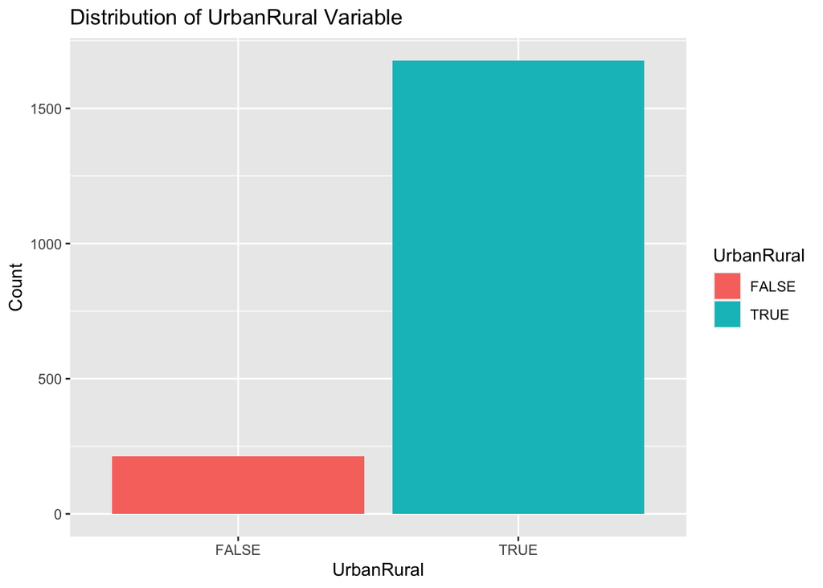

```r
# Create a bar chart for the "UrbanRural" variable
bar_chart_urban_rural <- train %>%
  group_by(UrbanRural) %>%
  summarize(Count = n()) %>%
  ggplot(aes(x = UrbanRural, y = Count, fill = UrbanRural)) +
  geom_bar(stat = "identity") +
  labs(title = "Distribution of UrbanRural Variable", x = "UrbanRural", y = "Count")

print(bar_chart_urban_rural)
```

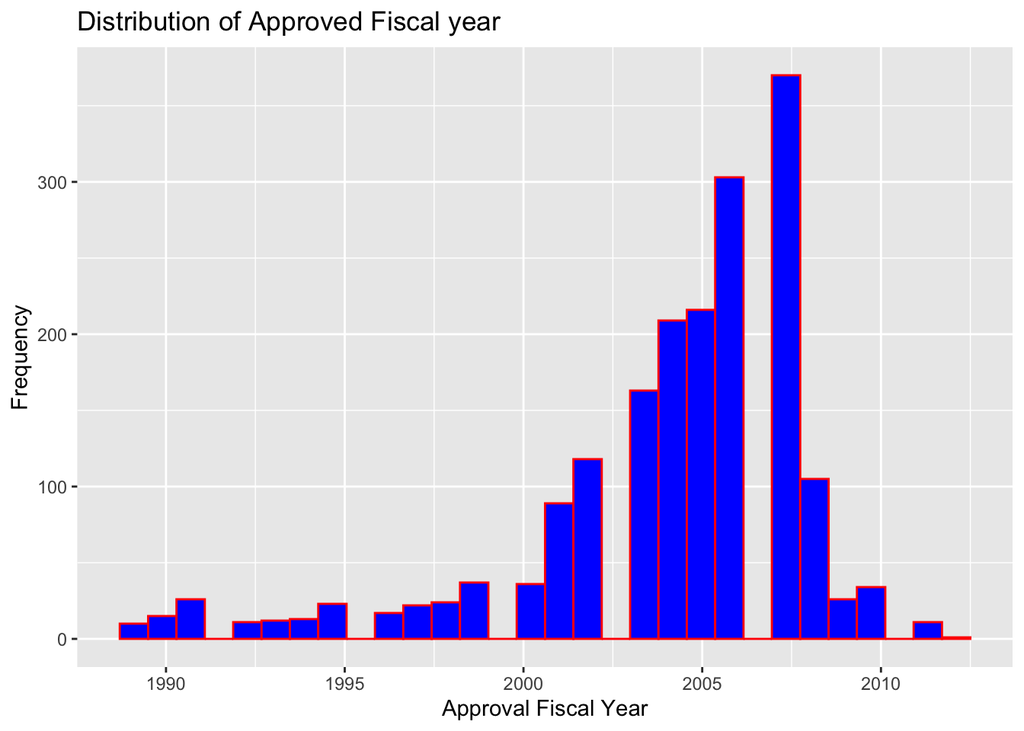

```r
ggplot(train, aes(x=ApprovalFY)) +
  geom_histogram(birwidth = 1, fill = "blue", color ="red") +
  labs(title = "Distribution of Approved Fiscal year", x = "Approval Fiscal Year",y = "Frequency")
```

4. Pick a couple of categorical feature variables, like UrbanRural and look the default rates (fraction of loans that default) between different levels of those variables to get a sense of the data.

```r
# Column - UrbanRural

train %>%
  count(UrbanRural) %>%
  print()
```

```
##   UrbanRural    n
## 1      FALSE  214
## 2       TRUE 1677
```

```r
# Column - RealEstate

train %>%
  count(RealEstate) %>%
  print()
```

```
##   RealEstate    n
## 1      FALSE 1364
## 2       TRUE  527
```

#### 8. Pick a couple rows of your testing data and look at them — save these rows for later so you can explore the model outputs.

```r
head(test)
```

```
##   ApprovalFY Term NoEmp CreateJob RetainedJob FranchiseCode UrbanRural
## 1       2005   84     8         0           0             1       TRUE
## 2       2005   42     7         0           0             1       TRUE
## 3       2005   42    10         0           0             1       TRUE
## 4       2005   84     6         0           6             1       TRUE
## 5       2005   68     4         0           4             1       TRUE
## 6       2005   18     1         0           1             1       TRUE
##   RevLineCr LowDoc DisbursementDate DisbursementGross BalanceGross GrAppv
## 1     FALSE  FALSE            16467            100000            0 100000
## 2     FALSE  FALSE            16436            100000            0 100000
## 3     FALSE  FALSE            16436            100000            0 100000
## 4      TRUE  FALSE            16495             64000            0  50000
## 5      TRUE  FALSE            16526             45018            0  45000
## 6      TRUE  FALSE            16617             13107            0  10000
##   SBA_Appv   New RealEstate Portion Recession Outcome
## 1    50000 FALSE      FALSE     0.5     FALSE PaidOff
## 2    50000 FALSE      FALSE     0.5      TRUE Default
## 3    50000 FALSE      FALSE     0.5      TRUE Default
## 4    25000 FALSE      FALSE     0.5     FALSE PaidOff
## 5    22500 FALSE      FALSE     0.5     FALSE Default
## 6     5000 FALSE      FALSE     0.5     FALSE Default
```

### Major Task II - First Classifier

#### 1. Train a naïve Bayesian classifier with naive.bayes to predict default using the variables New, Recession, RevLineCr, and LowDoc.

```r
nb.cols = c("New","Recession","RevLineCr","LowDoc")
```

#### 2. Use this model to predict default for your example rows. Is it right?

```r
nb.train = train %>%
  select(Outcome, any_of(nb.cols)) %>%
  mutate(across(everything(),as.factor)) %>%
  as.data.frame()

glimpse(nb.train)
```

```
## Rows: 1,891
## Columns: 5
## $ Outcome   <fct> PaidOff, PaidOff, Default, PaidOff, Default, PaidOff, Defaul…
## $ New       <fct> FALSE, FALSE, FALSE, FALSE, FALSE, FALSE, FALSE, FALSE, FALS…
## $ Recession <fct> TRUE, FALSE, TRUE, FALSE, FALSE, FALSE, TRUE, FALSE, TRUE, F…
## $ RevLineCr <fct> TRUE, FALSE, TRUE, FALSE, TRUE, FALSE, FALSE, FALSE, FALSE, …
## $ LowDoc    <fct> FALSE, FALSE, FALSE, FALSE, FALSE, FALSE, FALSE, FALSE, FALS…
```

```r
mod.nb = naive.bayes(nb.train,"Outcome",nb.cols)

summary(mod.nb)
```

```
##          Length Class  Mode
## learning 6      -none- list
## nodes    5      -none- list
## arcs     8      -none- character
```

#### 3. Measure the accuracy, precision, and false positive rate of using your classifier to predict all of the testing data.

```r
nb.test = test %>%
  select(Outcome, any_of(nb.cols)) %>%
  mutate(across(everything(),as.factor)) %>%
  as.data.frame()

nb.test$Prediction = predict(mod.nb,nb.test)

glimpse(nb.test)
```

```
## Rows: 211
## Columns: 6
## $ Outcome    <fct> PaidOff, Default, Default, PaidOff, Default, Default, Defau…
## $ New        <fct> FALSE, FALSE, FALSE, FALSE, FALSE, FALSE, FALSE, FALSE, FAL…
## $ Recession  <fct> FALSE, TRUE, TRUE, FALSE, FALSE, FALSE, TRUE, FALSE, FALSE,…
## $ RevLineCr  <fct> FALSE, FALSE, FALSE, TRUE, TRUE, TRUE, FALSE, TRUE, FALSE, …
## $ LowDoc     <fct> FALSE, FALSE, FALSE, FALSE, FALSE, FALSE, FALSE, FALSE, FAL…
## $ Prediction <fct> PaidOff, PaidOff, PaidOff, Default, Default, Default, PaidO…
```

```r
accuracy(nb.test, Outcome, Prediction)
```

```
## # A tibble: 1 × 3
##   .metric  .estimator .estimate
##   <chr>    <chr>          <dbl>
## 1 accuracy binary         0.711
```

```r
a2_metrics = metric_set(accuracy, precision, sensitivity, specificity)
a2_metrics(nb.test, truth = Outcome, estimate = Prediction)
```

```
## # A tibble: 4 × 3
##   .metric     .estimator .estimate
##   <chr>       <chr>          <dbl>
## 1 accuracy    binary         0.711
## 2 precision   binary         0.558
## 3 sensitivity binary         0.676
## 4 specificity binary         0.729
```

### Major Task III - Trees and Forests

#### 1. Identify the variables that might be useful for prediction (basically everything that isn’t just the business identifier like name or code, or the free-text fields like location).

Based on the preceding exploration, the following variables have been retained: ApprovalFY, Term, NoEmp, CreateJob, RetainedJob, UrbanRural, RevLineCr, LowDoc, DisbursementDate, DisbursementGross, BalanceGross, GrAppv, SBA_Appv, New, RealEstate, Portion, and Recession. The remaining variables were removed from the dataset during the cleaning and exploration process.

#### 2. Use rpart to train a rdecision tree on these variables

```r
mod.dt = rpart(Outcome ~
                 ApprovalFY + Term + NoEmp + CreateJob + RetainedJob + UrbanRural + RevLineCr + LowDoc +
                 DisbursementDate + DisbursementGross + BalanceGross + GrAppv + SBA_Appv + New +
                 RealEstate + Portion + Recession
               ,train)
```

#### 3. Visualize the decision tree with plot.

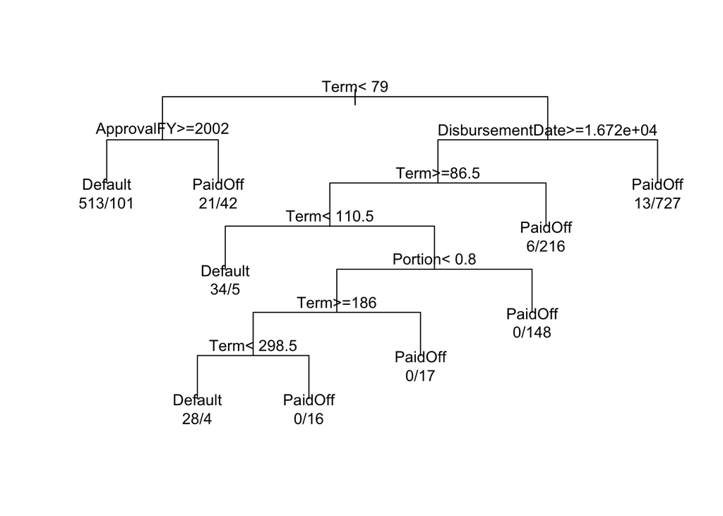

```r
par(xpd = TRUE)
plot(mod.dt, compress = TRUE, uniform = TRUE, cex = 2)
text(mod.dt, use.n = TRUE, cex = 0.9)
```

#### 4. Look at its output on your examples.

```r
dt.test = test %>%
  mutate(Prediction = predict(mod.dt, test, type= "class"))

glimpse(dt.test)
```

```
## Rows: 211
## Columns: 20
## $ ApprovalFY        <int> 2005, 2005, 2005, 2005, 2005, 2005, 2005, 2005, 2005…
## $ Term              <int> 84, 42, 42, 84, 68, 18, 42, 71, 84, 36, 84, 59, 120,…
## $ NoEmp             <int> 8, 7, 10, 6, 4, 1, 4, 12, 80, 5, 1, 5, 6, 130, 3, 2,…
## $ CreateJob         <int> 0, 0, 0, 0, 0, 0, 0, 0, 0, 0, 1, 0, 0, 0, 2, 0, 0, 0…
## $ RetainedJob       <int> 0, 0, 0, 6, 4, 1, 4, 12, 80, 5, 1, 5, 6, 0, 3, 2, 9,…
## $ FranchiseCode     <int> 1, 1, 1, 1, 1, 1, 1, 1, 1, 0, 0, 0, 1, 1, 0, 0, 0, 0…
## $ UrbanRural        <lgl> TRUE, TRUE, TRUE, TRUE, TRUE, TRUE, TRUE, TRUE, TRUE…
## $ RevLineCr         <lgl> FALSE, FALSE, FALSE, TRUE, TRUE, TRUE, FALSE, TRUE, …
## $ LowDoc            <lgl> FALSE, FALSE, FALSE, FALSE, FALSE, FALSE, FALSE, FAL…
## $ DisbursementDate  <int> 16467, 16436, 16436, 16495, 16526, 16617, 16587, 165…
## $ DisbursementGross <int> 100000, 100000, 100000, 64000, 45018, 13107, 33500, …
## $ BalanceGross      <int> 0, 0, 0, 0, 0, 0, 0, 0, 0, 0, 0, 0, 0, 0, 0, 0, 0, 0…
## $ GrAppv            <int> 100000, 100000, 100000, 50000, 45000, 10000, 22000, …
## $ SBA_Appv          <int> 50000, 50000, 50000, 25000, 22500, 5000, 11000, 2500…
## $ New               <lgl> FALSE, FALSE, FALSE, FALSE, FALSE, FALSE, FALSE, FAL…
## $ RealEstate        <lgl> FALSE, FALSE, FALSE, FALSE, FALSE, FALSE, FALSE, FAL…
## $ Portion           <dbl> 0.50, 0.50, 0.50, 0.50, 0.50, 0.50, 0.50, 0.50, 0.50…
## $ Recession         <lgl> FALSE, TRUE, TRUE, FALSE, FALSE, FALSE, TRUE, FALSE,…
## $ Outcome           <fct> PaidOff, Default, Default, PaidOff, Default, Default…
## $ Prediction        <fct> PaidOff, Default, Default, PaidOff, Default, Default…
```

#### 5. Measure the accuracy, precision, sensitivity, and specificity on your testing data.

```r
a2_metrics(dt.test,truth = Outcome, estimate = Prediction)
```

```
## # A tibble: 4 × 3
##   .metric     .estimator .estimate
##   <chr>       <chr>          <dbl>
## 1 accuracy    binary         0.915
## 2 precision   binary         0.835
## 3 sensitivity binary         0.930
## 4 specificity binary         0.907
```

### Major Task IV - Advance Decision Trees

#### 1. Train a random forest on the same variables as your decision tree from Pt. III.

```r
mod.rf = randomForest(Outcome ~
                 ApprovalFY + Term + NoEmp + CreateJob + RetainedJob + UrbanRural + RevLineCr + LowDoc +
                 DisbursementDate + DisbursementGross + BalanceGross + GrAppv + SBA_Appv + New +
                 RealEstate + Portion + Recession
               ,train, na.action = na.omit)
summary(mod.rf)
```

```
##                 Length Class  Mode
## call               4   -none- call
## type               1   -none- character
## predicted       1888   factor numeric
## err.rate        1500   -none- numeric
## confusion          6   -none- numeric
## votes           3776   matrix numeric
## oob.times       1888   -none- numeric
## classes            2   -none- character
## importance        17   -none- numeric
## importanceSD       0   -none- NULL
## localImportance    0   -none- NULL
## proximity          0   -none- NULL
## ntree              1   -none- numeric
## mtry               1   -none- numeric
## forest            14   -none- list
## y               1888   factor numeric
## test               0   -none- NULL
## inbag              0   -none- NULL
## terms              3   terms  call
## na.action          3   omit   numeric
```

#### 2. Predict your example rows — is it right?

```r
rf.test = test %>%
  mutate(Prediction = predict(mod.rf,test, type="class"))

glimpse(rf.test)
```

```
## Rows: 211
## Columns: 20
## $ ApprovalFY        <int> 2005, 2005, 2005, 2005, 2005, 2005, 2005, 2005, 2005…
## $ Term              <int> 84, 42, 42, 84, 68, 18, 42, 71, 84, 36, 84, 59, 120,…
## $ NoEmp             <int> 8, 7, 10, 6, 4, 1, 4, 12, 80, 5, 1, 5, 6, 130, 3, 2,…
## $ CreateJob         <int> 0, 0, 0, 0, 0, 0, 0, 0, 0, 0, 1, 0, 0, 0, 2, 0, 0, 0…
## $ RetainedJob       <int> 0, 0, 0, 6, 4, 1, 4, 12, 80, 5, 1, 5, 6, 0, 3, 2, 9,…
## $ FranchiseCode     <int> 1, 1, 1, 1, 1, 1, 1, 1, 1, 0, 0, 0, 1, 1, 0, 0, 0, 0…
## $ UrbanRural        <lgl> TRUE, TRUE, TRUE, TRUE, TRUE, TRUE, TRUE, TRUE, TRUE…
## $ RevLineCr         <lgl> FALSE, FALSE, FALSE, TRUE, TRUE, TRUE, FALSE, TRUE, …
## $ LowDoc            <lgl> FALSE, FALSE, FALSE, FALSE, FALSE, FALSE, FALSE, FAL…
## $ DisbursementDate  <int> 16467, 16436, 16436, 16495, 16526, 16617, 16587, 165…
## $ DisbursementGross <int> 100000, 100000, 100000, 64000, 45018, 13107, 33500, …
## $ BalanceGross      <int> 0, 0, 0, 0, 0, 0, 0, 0, 0, 0, 0, 0, 0, 0, 0, 0, 0, 0…
## $ GrAppv            <int> 100000, 100000, 100000, 50000, 45000, 10000, 22000, …
## $ SBA_Appv          <int> 50000, 50000, 50000, 25000, 22500, 5000, 11000, 2500…
## $ New               <lgl> FALSE, FALSE, FALSE, FALSE, FALSE, FALSE, FALSE, FAL…
## $ RealEstate        <lgl> FALSE, FALSE, FALSE, FALSE, FALSE, FALSE, FALSE, FAL…
## $ Portion           <dbl> 0.50, 0.50, 0.50, 0.50, 0.50, 0.50, 0.50, 0.50, 0.50…
## $ Recession         <lgl> FALSE, TRUE, TRUE, FALSE, FALSE, FALSE, TRUE, FALSE,…
## $ Outcome           <fct> PaidOff, Default, Default, PaidOff, Default, Default…
## $ Prediction        <fct> PaidOff, Default, Default, PaidOff, Default, Default…
```

#### 3. Measure the accuracy, precision, sensitivity, and specificity on your testing data.

```r
a2_metrics(rf.test,truth = Outcome, estimate = Prediction)
```

```
## # A tibble: 4 × 3
##   .metric     .estimator .estimate
##   <chr>       <chr>          <dbl>
## 1 accuracy    binary         0.938
## 2 precision   binary         0.903
## 3 sensitivity binary         0.915
## 4 specificity binary         0.95
```

#### 4. Repeat for XGBoost (optional — setting up the data is harder)

```r
dtrain = xgb.DMatrix(data = as.matrix(train %>% select(-Outcome)), label = as.numeric(train$Outcome) - 1)
dtest = xgb.DMatrix(data = as.matrix(test %>% select(-Outcome)), label = as.numeric(test$Outcome) - 1)

params = list(
  objective = "binary:logistic",
  eval_metric = "logloss",
  max_depth = 6,
  eta = 0.3
)
xgb_model = xgboost(params = params, data = dtrain, nrounds = 100)
```

# Predictions on the test data

```r
xgb_test_preds = predict(xgb_model, dtest)
```

# Convert predicted probabilities to class labels using a threshold of 0.5 (0 or 1)

```r
xgb_test_pred_labels = ifelse(xgb_test_preds > 0.5, 1, 0)
```

#create a dataframe with the truth and predited labels for the test data

```r
results_test = data.frame(Outcome = as.numeric(test$Outcome) - 1, Prediction = xgb_test_pred_labels)
```

# Calculate accuracy, precision, sensitivity, and specificity

–convert ‘Outcome’ in ‘results_test’ to a factor

```r
results_test$Outcome <- as.factor(results_test$Outcome)
results_test$Prediction <- as.factor(xgb_test_pred_labels)
```

–compute the metrics

```r
a2_metrics(results_test, truth = Outcome, estimate = Prediction)
```

[output not shown]

### Major Task V - Wrapping Up

```r
test_all = nb.test %>%
  select(Outcome, nb_pred=Prediction) %>%
  inner_join(dt.test %>% select(Outcome, dt_pred=Prediction)) %>%
  inner_join(rf.test %>% select(Outcome, rf_pred=Prediction)) %>%
  #inner_join(results_test %>% select(Outcome, xgb_pred=Prediction)) %>%
  mutate(counter = row_number()) %>%
  glimpse()
```

```
## Rows: 3,101,911
## Columns: 5
## $ Outcome <fct> PaidOff, PaidOff, PaidOff, PaidOff, PaidOff, PaidOff, PaidOff,…
## $ nb_pred <fct> PaidOff, PaidOff, PaidOff, PaidOff, PaidOff, PaidOff, PaidOff,…
## $ dt_pred <fct> PaidOff, PaidOff, PaidOff, PaidOff, PaidOff, PaidOff, PaidOff,…
## $ rf_pred <fct> PaidOff, PaidOff, PaidOff, Default, PaidOff, PaidOff, PaidOff,…
## $ counter <int> 1, 2, 3, 4, 5, 6, 7, 8, 9, 10, 11, 12, 13, 14, 15, 16, 17, 18,…
```

```r
test_long = test_all %>%
  pivot_longer(nb_pred | dt_pred | rf_pred, names_to = "model", values_to = "predicted") %>%
  glimpse()
```

```
## Rows: 9,305,733
## Columns: 4
## $ Outcome   <fct> PaidOff, PaidOff, PaidOff, PaidOff, PaidOff, PaidOff, PaidOf…
## $ counter   <int> 1, 1, 1, 2, 2, 2, 3, 3, 3, 4, 4, 4, 5, 5, 5, 6, 6, 6, 7, 7, …
## $ model     <chr> "nb_pred", "dt_pred", "rf_pred", "nb_pred", "dt_pred", "rf_p…
## $ predicted <fct> PaidOff, PaidOff, PaidOff, PaidOff, PaidOff, PaidOff, PaidOf…
```

```r
all_metrics = test_long %>%
  group_by(model) %>%
  a2_metrics(truth = Outcome, estimate=predicted) %>%
  select(model, metric=.metric, value=.estimate)
all_metrics %>% pivot_wider(id_cols = model, names_from = metric, values_from = value)
```

```
## # A tibble: 3 × 5
##   model   accuracy precision sensitivity specificity
##   <chr>      <dbl>     <dbl>       <dbl>       <dbl>
## 1 dt_pred    0.910     0.566       0.930       0.907
## 2 nb_pred    0.723     0.245       0.676       0.729
## 3 rf_pred    0.946     0.705       0.915       0.95
```

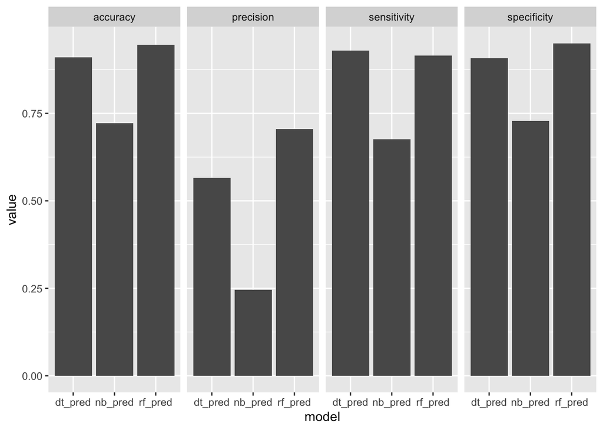

```r
ggplot(all_metrics) +
  aes(x=model, y=value) +
  # identity stat needed when we have computed the bar values!
  geom_bar(stat='identity') +
  facet_grid(~ metric)
```